# Building Bricks Of Colour Clustering

Kajetan Siwek

2026-11-24

Completed as part of the Unsupervised Learning [2400-DS1UL] course requirements for the Data Science and Business Analytics programme (Faculty of Economic Sciences, University of Warsaw). The paper is primarily based on course materials, supported by additional external sources.

# Introduction

This paper (also referred to as the project) is a study exploring the possibilities and limitations of clustering for image segmentation, and the analysis of market and visual characteristics of LEGO colours. In simple terms, clustering is an unsupervised learning algorithm used to group observations of similar characteristics into clusters. For this study, the methods of partitioning around medoids are used, where cluster centres are real data points (medoids) as opposed to arbitrary artificial points not present in the original data (centroids). The project encompasses three topics divided into three chapters. Chapter 1 evaluates how different colour-spaces influence image segmentation performance when applying partitioning around medoids. It identifies the optimal colour-space for segmenting LEGO set product images for the best preservation of the original colour-schemes. Chapter 2 analyses LEGO colours based on their market and visual attributes using the BrickLink marketplace dataset. A clustering algorithm is applied to determine whether LEGO colours can be divided into sensible, distinct market groups and colour palettes. Chapter 3 describes an experimental study, exploring how cluster analysis and image segmentation can be used to create alternative colour-schemes of LEGO sets.

## Transparency Clause on the Use of Generative AI

- *Defining Functions*: Throughout this project, numerous metrics and plots are repeated multiple times for individual objects of the same type. To simplify and produce cleaner code, new functions are defined and widely used. Some of the functions have been generated with GenAI based on scripts I first wrote on one example. The specific functions created this way are: `plot3DColourModel`, `getImageInColorModels`, `AverageSilhouetteCLARA`, `CLARAImageColourSpace`, `CLARAMedoidsToHEX`, `plotCLARAImage`. The function `evaluateImageClusteringByClusters` was generated without an example, but based on the methodology provided in subsection 1.4.2 ‘CIEDE2000 Evaluation’.
- *Graphics Distribution*: In Chapter 3, GenAI was used to help with the layout of the plots shown, so they can be viewed next to each other, yet remain readable.
- *General language revision*: In the final stage of working on the project, I ran it through GenAI for technical proof-reading and to catch any possible typos, grammar mistakes, awkward sentences, etc.

# Chapter 1: Evaluation of Colour-Spaces for Image Segmentation of LEGO Sets

Image segmentation is a process of partitioning a digital image into visual regions based on pixel features (Gonzalez & Woods, 2018). This chapter segments pixel data using the CLARA (Clustering Large Applications) algorithm to extract representative colour palettes from LEGO set photos. Each pixel represents an observation defined by its values in a given colour space.

The focus of clustering in this and the following sections of this project is to extract colour palettes based on the segmentation and colours actually present in the image. In this case, palette extraction requires cluster centres to be actual observed pixels (medoids) rather than computed mean points (centroids). Centroid-based clustering can produce arbitrary colour values not corresponding to any of the actual pixels from the source image. Medoid-based partitioning guarantees that every cluster center corresponds to a real pixel value present in the set photo.

Standard Partitioning Around Medoids (PAM) computes a full pairwise dissimilarity matrix (N×N). This approach does not scale to digital images, where even a modest resolution can yield large data frames. CLARA resolves scalability constraints by sampling multiple subsets from the image dataset, running PAM on each subsample to find candidate medoids, and selecting the medoids that minimise overall dissimilarity across the entire dataset.

## 1.1 Introduction to the Selection of Colour-Spaces

A colour-space (in this paper used interchangeably with colour-model) provides a schematic system to organise and reproduce colours across digital displays and physical media. As different colour-spaces use different metrics to represent colour, clustering with the use of Euclidean distance ought to yield colour-space-specific medoids based on the transformation.(Khattab et al., 2014) (Wikipedia contributors, 2026).

For this experiment, seven colour-spaces have been chosen:

- RGB (Red, Green, Blue): An additive colour-model where the colour of the pixel is defined by an integer for a given channel (R, G and B) in the range from 0 to 255.
- sRGB (Standard RGB): A standardised scale of RGB where the channel values are normalised to range from 0 to 1.
- CMY (Cyan, Magenta, Yellow): A subtractive colour model used commonly in printing. Each channel is a linear inverse of the RGB channels (so $C=255−R$, $M=255−G$, $Y=255−B$)
- CIELAB (L*a*B*): A perceptually uniform colour-model, where L* represents perceptual lightness, a* represents the green-red axis, and b* represents the blue-yellow axis. Established by the International Commission on Illumination (CIE) in 1976. Conceptually, distances in CIELAB should approximate human perceptual differences.
- OKLAB: An *improvement* to CIELAB (Ottosson, 2020). Fixes hue-linearity distortions of saturated colours and balances perceptual lightness gradients.
- HSV (Hue, Saturation, Value): A cylindrical transform of RGB that separates chromatic content (Hue) from colour intensity (Saturation) and brightness (Value).
- XYZ (CIE 1931 XYZ): The ‘oldest’ colour-space from the list, the foundational reference colour-space from which all other standard colour-spaces are derived.

For the conversion between the colours in this and all the following chapters, the `farver` package is utilised. `farver` is a specialised package to handle colour operations of various kinds in R and will prove useful in different sections throughout this project.

Each colour-model represents individual colours using three coordinate values; therefore, we can map these coordinate values into a 3D scatter plot. Interactive renders are provided via the `plotly` package.

Digital plots display colour points using 24-bit hexadecimal string encodings (`#RRGGBB`), derived from 8-bit RGB channels. Plotting R native colours across each space reveals how mathematical transformations reshape colour distributions within 3D geometric boundaries.

To plot the colours, first we produce data frames of native R colours in the encodings of the considered colour-spaces.

```r
RColours <- colours()

RColours_RGB <- t(col2rgb(colours()))
rownames(RColours_RGB) <- RColours

RColours <- data.frame(row.names = RColours,
                       "hexCode" = rgb(RColours_RGB, maxColorValue = 255))

RColours_sRGB <- RColours_RGB / 255
RColours_RGB <- as.data.frame(RColours_RGB)
RColours_sRGB <- as.data.frame(RColours_sRGB)
RColours_CMY <- data.frame(row.names=rownames(RColours),
                              farver::convert_colour(RColours_RGB,
                                                     from = "rgb",
                                                     to = "cmy"))
RColours_CIELAB <- data.frame(row.names=rownames(RColours),
                              farver::convert_colour(RColours_RGB,
                                                     from = "rgb",
                                                     to = "lab"))
RColours_OKLAB <- data.frame(row.names=rownames(RColours),
                              farver::convert_colour(RColours_RGB,
                                                     from = "rgb",
                                                     to = "oklab"))
RColours_HSV <- data.frame(row.names=rownames(RColours),
                              farver::convert_colour(RColours_RGB,
                                                     from = "rgb",
                                                     to = "hsv"))
RColours_XYZ <- data.frame(row.names=rownames(RColours),
                              farver::convert_colour(RColours_RGB,
                                                     from = "rgb",
                                                     to = "xyz"))
```

### 1.1.1 Questions and Hypotheses regarding colour-space representations

Questions and hypotheses:

> *Q1: To what extent does the choice of colour-space affect the quality of medoid-based image segmentation?*

> **H1a**: Different colour-spaces produce significantly different segmentation results.  
> **H1b**: RGB, sRGB and CMY produce identical clustering results due to their linear transformations preserving Euclidean distances between colour values.

> *Q2: Which colour-space provides the best colour reconstruction quality when representing LEGO product images using a restricted number of colours?*

> **H2a**: Perceptually oriented colour-spaces (CIELAB and OKLAB) achieve lower perceptual reconstruction errors than conventional colour-spaces (RGB, sRGB and CMY).  
> **H2b**: OKLAB yields lower perceptual reconstruction error than CIELAB.  
> **H2c**: HSV and XYZ yield the poorest colour reconstruction performance among the evaluated colour-spaces.

### 1.1.2 Preview of data sets of R native colours in different colour-spaces

#### R Colours

```r
kable(head(RColours, 10))
```

|  | hexCode |
| --- | --- |
| white | #FFFFFF |
| aliceblue | #F0F8FF |
| antiquewhite | #FAEBD7 |
| antiquewhite1 | #FFEFDB |
| antiquewhite2 | #EEDFCC |
| antiquewhite3 | #CDC0B0 |
| antiquewhite4 | #8B8378 |
| aquamarine | #7FFFD4 |
| aquamarine1 | #7FFFD4 |
| aquamarine2 | #76EEC6 |

#### RGB

```r
kable(head(RColours_RGB, 10))
```

|  | red | green | blue |
| --- | --- | --- | --- |
| white | 255 | 255 | 255 |
| aliceblue | 240 | 248 | 255 |
| antiquewhite | 250 | 235 | 215 |
| antiquewhite1 | 255 | 239 | 219 |
| antiquewhite2 | 238 | 223 | 204 |
| antiquewhite3 | 205 | 192 | 176 |
| antiquewhite4 | 139 | 131 | 120 |
| aquamarine | 127 | 255 | 212 |
| aquamarine1 | 127 | 255 | 212 |
| aquamarine2 | 118 | 238 | 198 |

#### sRGB

```r
kable(head(RColours_sRGB, 10))
```

|  | red | green | blue |
| --- | --- | --- | --- |
| white | 1.0000000 | 1.0000000 | 1.0000000 |
| aliceblue | 0.9411765 | 0.9725490 | 1.0000000 |
| antiquewhite | 0.9803922 | 0.9215686 | 0.8431373 |
| antiquewhite1 | 1.0000000 | 0.9372549 | 0.8588235 |
| antiquewhite2 | 0.9333333 | 0.8745098 | 0.8000000 |
| antiquewhite3 | 0.8039216 | 0.7529412 | 0.6901961 |
| antiquewhite4 | 0.5450980 | 0.5137255 | 0.4705882 |
| aquamarine | 0.4980392 | 1.0000000 | 0.8313725 |
| aquamarine1 | 0.4980392 | 1.0000000 | 0.8313725 |
| aquamarine2 | 0.4627451 | 0.9333333 | 0.7764706 |

#### CMY

```r
kable(head(RColours_CMY, 10))
```

|  | c | m | y |
| --- | --- | --- | --- |
| white | 0.0000000 | 0.0000000 | 0.0000000 |
| aliceblue | 0.0588235 | 0.0274510 | 0.0000000 |
| antiquewhite | 0.0196078 | 0.0784314 | 0.1568627 |
| antiquewhite1 | 0.0000000 | 0.0627451 | 0.1411765 |
| antiquewhite2 | 0.0666667 | 0.1254902 | 0.2000000 |
| antiquewhite3 | 0.1960784 | 0.2470588 | 0.3098039 |
| antiquewhite4 | 0.4549020 | 0.4862745 | 0.5294118 |
| aquamarine | 0.5019608 | 0.0000000 | 0.1686275 |
| aquamarine1 | 0.5019608 | 0.0000000 | 0.1686275 |
| aquamarine2 | 0.5372549 | 0.0666667 | 0.2235294 |

#### CIELAB

```r
kable(head(RColours_CIELAB, 10))
```

|  | l | a | b |
| --- | --- | --- | --- |
| white | 100.00000 | 0.0072527 | 0.0043151 |
| aliceblue | 97.17865 | -1.3415429 | -4.2585587 |
| antiquewhite | 93.73133 | 1.8455802 | 11.5299930 |
| antiquewhite1 | 95.20676 | 2.1854817 | 11.6165008 |
| antiquewhite2 | 89.53956 | 2.0372811 | 11.1566301 |
| antiquewhite3 | 78.35306 | 1.8895286 | 9.7078710 |
| antiquewhite4 | 55.15255 | 1.0206467 | 7.0284881 |
| aquamarine | 92.03398 | -45.5184295 | 9.7219319 |
| aquamarine1 | 92.03398 | -45.5184295 | 9.7219319 |
| aquamarine2 | 86.54051 | -43.1603146 | 9.0840388 |

#### OKLAB

```r
kable(head(RColours_OKLAB, 10))
```

|  | l | a | b |
| --- | --- | --- | --- |
| white | 0.9999882 | 0.0000083 | -0.0001177 |
| aliceblue | 0.9751325 | -0.0054923 | -0.0115206 |
| antiquewhite | 0.9466780 | 0.0079366 | 0.0299474 |
| antiquewhite1 | 0.9595242 | 0.0089571 | 0.0301776 |
| antiquewhite2 | 0.9106124 | 0.0084099 | 0.0289769 |
| antiquewhite3 | 0.8141184 | 0.0076836 | 0.0252258 |
| antiquewhite4 | 0.6137832 | 0.0045701 | 0.0182715 |
| aquamarine | 0.9149933 | -0.1279960 | 0.0247943 |
| aquamarine1 | 0.9149933 | -0.1279960 | 0.0247943 |
| aquamarine2 | 0.8684781 | -0.1214164 | 0.0231611 |

#### HSV

```r
kable(head(RColours_HSV, 10))
```

|  | h | s | v |
| --- | --- | --- | --- |
| white | 0.00000 | 0.0000000 | 1.0000000 |
| aliceblue | 208.00000 | 0.0588235 | 1.0000000 |
| antiquewhite | 34.28571 | 0.1400000 | 0.9803922 |
| antiquewhite1 | 33.33333 | 0.1411765 | 1.0000000 |
| antiquewhite2 | 33.52941 | 0.1428571 | 0.9333333 |
| antiquewhite3 | 33.10345 | 0.1414634 | 0.8039216 |
| antiquewhite4 | 34.73684 | 0.1366906 | 0.5450980 |
| aquamarine | 159.84375 | 0.5019608 | 1.0000000 |
| aquamarine1 | 159.84375 | 0.5019608 | 1.0000000 |
| aquamarine2 | 160.00000 | 0.5042017 | 0.9333333 |

#### XYZ

```r
kable(head(RColours_XYZ, 10))
```

|  | x | y | z |
| --- | --- | --- | --- |
| white | 95.04700 | 100.00001 | 108.88300 |
| aliceblue | 87.54900 | 92.87943 | 107.90349 |
| antiquewhite | 81.39757 | 84.64825 | 76.32758 |
| antiquewhite1 | 84.89183 | 88.10887 | 79.53877 |
| antiquewhite2 | 72.54594 | 75.31332 | 67.83030 |
| antiquewhite3 | 51.86242 | 53.81384 | 48.72091 |
| antiquewhite4 | 22.15367 | 23.07796 | 21.05310 |
| aquamarine | 56.39075 | 80.78061 | 74.89515 |
| aquamarine1 | 56.39075 | 80.78061 | 74.89515 |
| aquamarine2 | 48.23424 | 69.07366 | 64.20585 |

### 1.1.3 Visualisation of R native colours

It should be noted that a simple 3D Cartesian representation is used for rendering all the colour-spaces. Although this choice is not ideal for colour-space visualisation, as they typically require specialised non-Cartesian geometry to be properly rendered, this choice is deliberate as the partitioning algorithm chosen for this chapter utilises the Euclidean distance metric.

CLARA/PAM calculation of dissimilarity treats the colour-spaces encodings as raw coordinate columns and uses 3D Euclidean distance. Rendering the colour-spaces in Cartesian space reveals why clustering based on Euclidean distance could yield worse results for spaces like HSV.

```r
# GENERARTIVE AI USE 2026-11-05
# I first wrote out a plot function for singual Colour-Model myself
# and then prompted ChatGPT to create a simple function
# as to not repeat the whole code for plotting 7 times
# I did minimal corrections to the generated function

plot3DColourModel <- function(data,
                              x, y, z,
                              title = "3D Colour Model",
                              color = NULL,
                              marker.size = 7,
                              marker.opacity = 1) {

  # If no colours are supplied, use rownames to extract them from RColours
  if (is.null(color)) {
    color <- RColours$hexCode[
      match(rownames(data), rownames(RColours))
    ]
  }

  plot_ly(
    x = data[[x]],
    y = data[[y]],
    z = data[[z]],
    width = 700,
    height = 700,
    type = "scatter3d",
    mode = "markers",
    marker = list(
      size = marker.size,
      color = color,
      opacity = marker.opacity
    ),
    text = rownames(data),
    hoverinfo = "text"
  ) %>%
    layout(
      title = title,
      scene = list(
        xaxis = list(title = x),
        yaxis = list(title = y),
        zaxis = list(title = z)
      )
    )
}
```

### 1.1.4 Plots

#### RGB

```r
plot3DColourModel(
  RColours_RGB,
  "red", "green", "blue",
  title = "3D representation of R native colors\nin RGB Colour Space"
)
```

[interactive chart not shown]

#### sRGB

```r
plot3DColourModel(
  RColours_sRGB,
  "red", "green", "blue",
  title = "3D representation of R native colors\nin sRGB Colour Space"
)
```

[interactive chart not shown]

#### CMY

```r
plot3DColourModel(
  RColours_CMY,
  "c", "m", "y",
  title = "3D representation of R native colors\nin CMY Colour Space"
)
```

[interactive chart not shown]

#### CIELAB

```r
plot3DColourModel(
  RColours_CIELAB,
  "a", "b", "l",
  title = "3D representation of R native colors\nin CIELAB Colour Space"
)
```

[interactive chart not shown]

#### OKLAB

```r
plot3DColourModel(
  RColours_OKLAB,
  "a", "b", "l",
  title = "3D representation of R native colors\nin OKLAB Colour Space"
)
```

[interactive chart not shown]

#### HSV

```r
plot3DColourModel(
  RColours_HSV,
  "h", "s", "v",
  title = "3D representation of R native colors\nin HSV Colour Space"
)
```

[interactive chart not shown]

#### XYZ

```r
plot3DColourModel(
  RColours_XYZ,
  "x", "y", "z",
  title = "3D representation of R native colors\nin XYZ Colour Space"
)
```

[interactive chart not shown]

```r
rm(list = c("RColours_CIELAB","RColours_CMY",
            "RColours_HSV","RColours_OKLAB",
            "RColours_RGB", "RColours_sRGB",
            "RColours_XYZ"))
```

## 1.2 Showcase of LEGO sets product pictures for comparison

In the following chapter, we aim to recolour LEGO sets, so for this chapter we are testing how well different colour-space segmentations work for retaining the perceptual integrity of the sets.

We evaluate colour-space segmentation using official product photos of three representative LEGO sets:

- *Diversity of colours*: Sets containing distinct primary, secondary, and neutral hues.
- *Structural range*: Buildings, mechanical figures, and organic botanical builds.
- *Target demographics*: Display-focused adult sets and active playsets.

Images are sourced from [BrickOwl](https://www.brickowl.com) standard catalog photos. Studio photos present products isolated on plain white backgrounds.

Annotation A) The studio photos were chosen so as to focus on the product itself rather than colourful backgrounds of promotional material or set box images.

Annotation B) The positive of studio photos – the fact they show isolated sets presented on a white background – is also a huge drawback when performing image segmentation. White background pixels make up a significant fraction of the whole photo. As a result, the colour white `#FFFFFF` is bound to form its own cluster medoid in every model. While background removal masking could isolate product bricks, automated colour thresholding risks removing white LEGO element bricks. Therefore, we evaluate raw product photos directly, but the ‘White Cluster Issue’ is to be accounted for.

### 1.2.1 Chosen LEGO sets, description of images

Three LEGO sets were chosen for the evaluation of colour-spaces.

#### Seaside House 7346-1

[figure not shown]

```r
seasideHouse <- readJPEG("data/lego-seaside-house-set-7346-55377.jpg")

plot.new()
title("Seaside House 7346-1 Alternative Build B")
rasterImage(seasideHouse, 0, 0, 1, 1)
```

#### Cole’s Titan Dragon Mech 71821-1

[figure not shown]

```r
dragonMech <- readJPEG("data/lego-cole-s-titan-dragon-mech-set-71821-1523519.jpg")

plot.new()
title("Cole's Titan Dragon Mech 71821-1")
rasterImage(dragonMech, 0, 0, 1, 1)
```

#### Wildflower Bouquet 10313-1

[figure not shown]

```r
flowers <- readJPEG("data/lego-wildflower-bouquet-set-10313-1892227.jpg")

plot.new()
title("Wildflower Bouquet 10313-1")
rasterImage(flowers, 0, 0, 1, 1)
```

## 1.3 Prepare images for segmentations and perform clustering

### 1.3.1 Converting between colour-models

Images loaded via `readJPEG()` form 3D arrays ($height×width×channels$) in normalised sRGB (0,1). We flatten these arrays into a 2D matrix where each row represents a single spatial pixel coordinate (`dimx`, `dimy`) and its corresponding colour values across each colour-space.

```r
getImageInColorModels <- function(array) {

  dm1 <- dim(array)

  # info on image and its values in different colour spaces
  final_list <- list(dim = dm1)

  image_sRGB <- data.frame(dimx=rep(1:dm1[2], each=dm1[1]),
                         dimy=rep(dm1[1]:1, dm1[2]),
                         red=as.vector(array[,,1]),
                         green=as.vector(array[,,2]),
                         blue=as.vector(array[,,3]))

  final_list$sRGB <- image_sRGB
  image_RGB <- cbind(image_sRGB[,1:2],image_sRGB[,c("red", "green", "blue")] * 255)
  final_list$RGB <- image_RGB

  final_list$CMY <- data.frame(dimx = image_sRGB$dimx,
                               dimy = image_sRGB$dimy,
                         farver::convert_colour(image_RGB[3:5], from = "rgb", to = "cmy"))
  final_list$CIELAB <- data.frame(dimx = image_sRGB$dimx,
                               dimy = image_sRGB$dimy,
                            farver::convert_colour(image_RGB[3:5], from = "rgb", to = "lab"))
  final_list$OKLAB <- data.frame(dimx = image_sRGB$dimx,
                               dimy = image_sRGB$dimy,
                            farver::convert_colour(image_RGB[3:5], from = "rgb", to = "oklab"))
  final_list$HSV <- data.frame(dimx = image_sRGB$dimx,
                               dimy = image_sRGB$dimy,
                            farver::convert_colour(image_RGB[3:5], from = "rgb", to = "hsv"))
  final_list$XYZ <- data.frame(dimx = image_sRGB$dimx,
                               dimy = image_sRGB$dimy,
                         farver::convert_colour(image_RGB[3:5], from = "rgb", to = "xyz"))

  return(final_list)
}
```

*Preview of how the list objects look like*

```r
seasideHouse_info <- getImageInColorModels(seasideHouse)
dragonMech_info <- getImageInColorModels(dragonMech)
flowers_info <- getImageInColorModels(flowers)

# look how each item of the list look like
lapply(seasideHouse_info, head)
```

```
## $dim
## [1] 700 700   3
##
## $sRGB
##   dimx dimy red green blue
## 1    1  700   1     1    1
## 2    1  699   1     1    1
## 3    1  698   1     1    1
## 4    1  697   1     1    1
## 5    1  696   1     1    1
## 6    1  695   1     1    1
##
## $RGB
##   dimx dimy red green blue
## 1    1  700 255   255  255
## 2    1  699 255   255  255
## 3    1  698 255   255  255
## 4    1  697 255   255  255
## 5    1  696 255   255  255
## 6    1  695 255   255  255
##
## $CMY
##   dimx dimy c m y
## 1    1  700 0 0 0
## 2    1  699 0 0 0
## 3    1  698 0 0 0
## 4    1  697 0 0 0
## 5    1  696 0 0 0
## 6    1  695 0 0 0
##
## $CIELAB
##   dimx dimy   l           a          b
## 1    1  700 100 0.007252689 0.00431513
## 2    1  699 100 0.007252689 0.00431513
## 3    1  698 100 0.007252689 0.00431513
## 4    1  697 100 0.007252689 0.00431513
## 5    1  696 100 0.007252689 0.00431513
## 6    1  695 100 0.007252689 0.00431513
##
## $OKLAB
```

[output cut: 10 more lines]

```
## 1    1  700 0 0 1
## 2    1  699 0 0 1
## 3    1  698 0 0 1
## 4    1  697 0 0 1
## 5    1  696 0 0 1
## 6    1  695 0 0 1
##
## $XYZ
##   dimx dimy      x   y       z
## 1    1  700 95.047 100 108.883
## 2    1  699 95.047 100 108.883
## 3    1  698 95.047 100 108.883
## 4    1  697 95.047 100 108.883
## 5    1  696 95.047 100 108.883
## 6    1  695 95.047 100 108.883
```

### 1.3.2 Determine Optimal Cluster Count ($k$) for each image

To compare how well each of those works for image segmentation, we need to perform clustering on each of the colour-model encodings. To fairly compare these colour-models for a given image, we need to establish a constant number of clusters `k` for all colour-spaces.

To ensure a fair comparison of segmentation between selected colour-spaces, we ought to choose a fixed count $k$ for each image. We run CLARA across $k \in [2,8]$ and save information on average silhouette width for each colour-space. Using `DescTools::Mode` we select the $k$ value across colour-spaces as the optimal cluster count for that image.

```r
AverageSilhouetteCLARA <- function(image_3DColourSpace, vectorColumns = NA, mink = 2, maxk = 8) {

  if (is.na(vectorColumns)){vectorColumns <- names(image_3DColourSpace[,3:5])}

  vectorSilhouette <- c()

  for (k in mink:maxk){
    set.seed(seed)
    c <- clara(image_3DColourSpace[,vectorColumns], k)
    vectorSilhouette[k] <- c$silinfo$avg.width
  }

  return(data.frame(k= mink:maxk,
                    AverageWidthSilhouette = vectorSilhouette[mink:maxk]))

}
```

```r
seasideHouse_silthoette <- lapply(seasideHouse_info[-1], AverageSilhouetteCLARA)
dragonMech_silthoette <- lapply(dragonMech_info[-1], AverageSilhouetteCLARA)
flowers_silthoette <- lapply(flowers_info[-1], AverageSilhouetteCLARA)

# search for optimal K for each image
seasideHouse_optimalK <- lapply(seasideHouse_silthoette, \(x) x[which.max(x$AverageWidthSilhouette), ])
dragonMech_optimalK <- lapply(dragonMech_silthoette, \(x) x[which.max(x$AverageWidthSilhouette), ])
flowers_optimalK <- lapply(flowers_silthoette, \(x) x[which.max(x$AverageWidthSilhouette), ])

optimalK <-  data.frame("optimal k" = sapply(list(sapply(seasideHouse_optimalK, \(x) x$k),
                                                  sapply(dragonMech_optimalK, \(x) x$k),
                                                  sapply(flowers_optimalK, \(x) x$k)),
                                             DescTools::Mode),
                     row.names = c("Seaside House", "Cole's Titan Dragon Mech", "Wildflower Bouquet"))

kable(x = optimalK, row.names = T, caption = "Selected Optimal Cluster Count (k) per Image Set")
```

Selected Optimal Cluster Count (k) per Image Set

|  | optimal.k |
| --- | --- |
| Seaside House | 7 |
| Cole’s Titan Dragon Mech | 6 |
| Wildflower Bouquet | 8 |

### 1.3.3 CLARA Clustering and Palette Extraction

```r
CLARAImageColourSpace <- function(image_3DColourSpace, k) {

  final_list <- lapply(image_3DColourSpace[names(image_3DColourSpace) != "dim"],
                       function(x) {
                         set.seed(seed)
                         clara(x[, 3:5], k = k)})

  return(final_list)
}

seasideHouse_CLARA <- CLARAImageColourSpace(seasideHouse_info, optimalK["Seaside House",])
dragonMech_CLARA <- CLARAImageColourSpace(dragonMech_info, optimalK["Cole's Titan Dragon Mech",])
flowers_CLARA <- CLARAImageColourSpace(flowers_info, optimalK["Wildflower Bouquet",])
```

```r
CLARAMedoidsToHEX <- function(CLARA_results) {

  spaces <- c(
    RGB = "rgb",
    sRGB = "rgb",
    CMY = "cmy",
    CIELAB = "lab",
    OKLAB = "oklab",
    HSV = "hsv",
    XYZ = "xyz")

  lapply(names(CLARA_results),
         \(space) {
           medoids <- CLARA_results[[space]]$medoids
           if (space == "sRGB") {medoids <- medoids * 255}
           farver::encode_colour(medoids, from = spaces[space])}) %>%
    setNames(names(CLARA_results))
}

seasideHouse_HEX <- CLARAMedoidsToHEX(seasideHouse_CLARA)
dragonMech_HEX <- CLARAMedoidsToHEX(dragonMech_CLARA)
flowers_HEX <- CLARAMedoidsToHEX(flowers_CLARA)
```

```r
plotCLARAImage <- function(array, CLARA_results) {


  dm1 <- dim(array)
  hex_list <- CLARAMedoidsToHEX(CLARA_results)

  paint_list <- lapply(names(CLARA_results), function(space) {
    clustering <- CLARA_results[[space]]$clustering
    hex <- hex_list[[space]]
    matrix(hex[clustering], nrow = dm1[1], ncol = dm1[2])})

  names(paint_list) <- names(CLARA_results)

  paint_list <- c(list(Original = as.raster(array)), paint_list)

  plot_colour <- function(img, label) {
  plot.new()
  plot.window(xlim = c(0, ncol(img)),
              ylim = c(0, nrow(img)),
              asp = 1,
              xaxs = "i",
              yaxs = "i")
  rasterImage(img, 0, 0, ncol(img), nrow(img))
  mtext(label, side=3, line=0, cex=1, font = 2)}


  # Original image
  par(mfrow=c(1,1),
      mar = c(0.3,0.3,2,0.3))
  plot_colour(paint_list$Original, "Original Image (sRGB)")

  # RGB family
  par(mfrow=c(1,3),
      mar = c(0.3,0.3,2,0.3))
  plot_colour(paint_list$RGB, "RGB")
  plot_colour(paint_list$sRGB, "sRGB")
  plot_colour(paint_list$CMY, "CMY")

  # Perceptually oriented colour spaces
  par(mfrow=c(1,2),
      mar = c(0.3,0.3,2,0.3))
  plot_colour(paint_list$CIELAB, "CIELAB")
  plot_colour(paint_list$OKLAB, "OKLAB")

  # Other colour spaces
  par(mfrow=c(1,2),
      mar = c(0.3,0.3,2,0.3))
  plot_colour(paint_list$HSV, "HSV")
  plot_colour(paint_list$XYZ, "XYZ")

  par(mfrow=c(1,1),
      mar = rep(0.25, 4))

  invisible(paint_list)
}
```

## 1.4 Evaluation of colour-spaces

The colour-spaces are evaluated with two methods:

- Visual Evaluation: qualitative assessment of extracted visual palettes in the reconstructed image.
- CIEDE2000 distance: standard quantitative metric assessing alignment of numerical distances of a colour to human-perceived colours.

### 1.4.1 Visual Evaluation

Reconstructing source images from assigned medoid colours reveals clear qualitative performance gaps between spaces.

**General description for the results**:

*CIELAB and OKLAB*:  
Worked the best for reconstruction of pictures with respect to their original colours. The main difference can be observed in their sensitivity to shadows and highlights. CIELAB *preserves colours more accurately*, although it *may flatten some of the lighting*. OKLAB *preserves shadows better*, but at the cost of some colour inaccuracies. OKLAB provides better results for overall image representation and clearer boundaries of specific objects, but CIELAB proves to be a better method for extracting real sample colours from the sets.

Examples:

- *Seaside House*: OKLAB clusters include more shades of blue, but there is no yellow cluster; CIELAB preserves all the colours;
- *Cole’s Titan Dragon Mech*: OKLAB also exhibits a brownish tint on the black armour; CIELAB preserves black armour;
- *Wildflower Bouquet* : CIELAB distinguishes *small lime-yellow flowers* at the bottom of the picture, while OKLAB assigns them greyish colours.

*HSV*: Image segmentation with CLARA clustering in HSV shows the limitation of applying Euclidean distance to a colour-space with non-Euclidean geometry. The reconstructed images are severely distorted, with poorly defined edges and unrefined segments appearing as scattered colour splashes across the plot.

*XYZ*: The produced reconstructions are desaturated and grey-toned. This issue is not as apparent in *Cole’s Titan Dragon Mech*, where the set looks similar to its original picture, but the other two – more colourful – sets are lacking in the original vibrant hues from the coloured bricks used.

#### Seaside House 7346-1

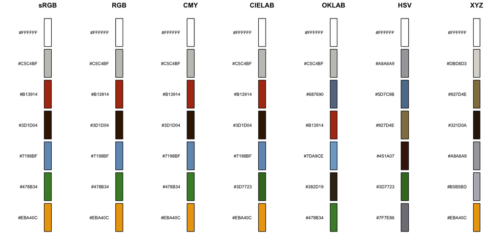

[figure not shown]

[figure not shown]

[figure not shown]

[figure not shown]

```r
old_par <- par(no.readonly = TRUE)
par(mfrow = c(1, 7),
    mar = rep(0.3, 4))

for (x in names(seasideHouse_HEX)) {
  swatch(seasideHouse_HEX[[x]])
  title(main = x)
}

seasideHouse_paint <- plotCLARAImage(
  seasideHouse,
  seasideHouse_CLARA
)
invisible(seasideHouse_paint)

par(old_par)
```

#### Cole’s Titan Dragon Mech 71821-1

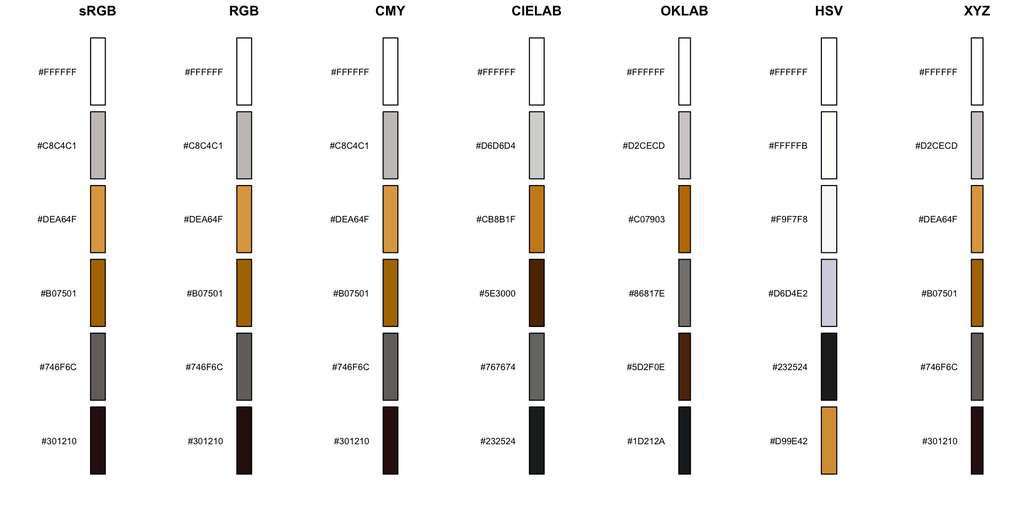

[figure not shown]

[figure not shown]

[figure not shown]

[figure not shown]

```r
par(mfrow = c(1, 7),
    mar = rep(0.3, 4))

for (x in names(dragonMech_HEX)) {
  swatch(dragonMech_HEX[[x]])
  title(main = x)
}

dragonMech_paint <- plotCLARAImage(
  dragonMech,
  dragonMech_CLARA
)
invisible(dragonMech_paint)

par(old_par)
```

#### Wildflower Bouquet 10313-1

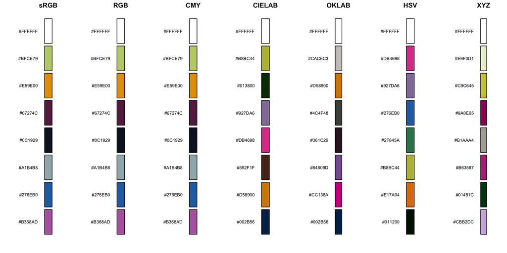

[figure not shown]

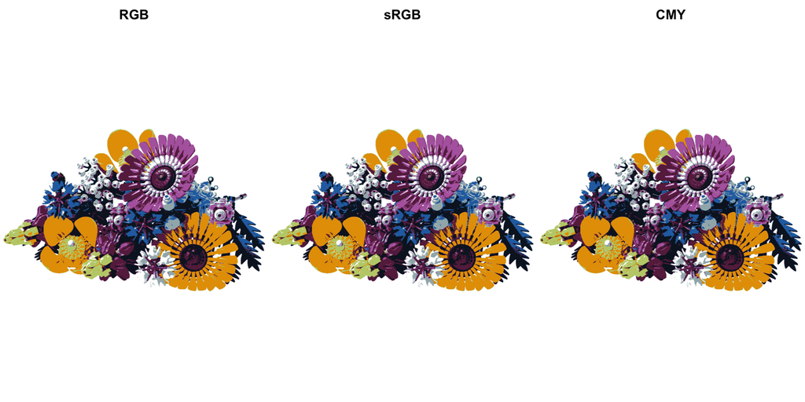

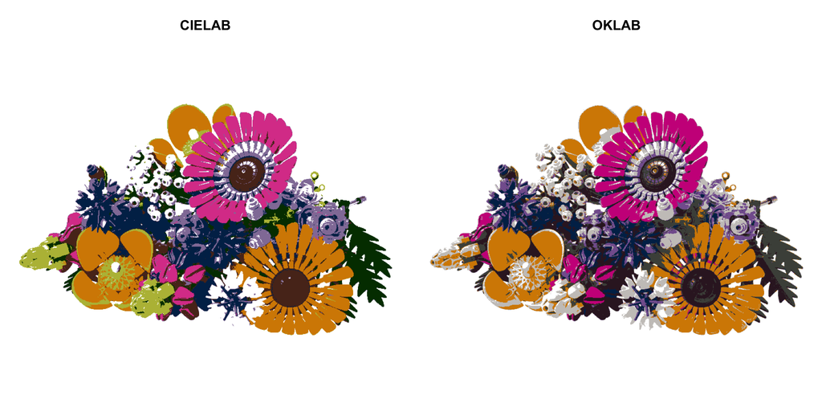

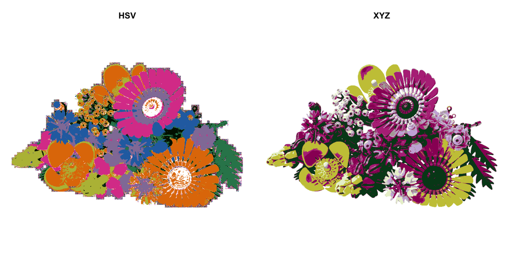

```r
par(mfrow = c(1, 7),
    mar = rep(0.3, 4))

for (x in names(flowers_HEX)) {
  swatch(flowers_HEX[[x]])
  title(main = x)
}

flowers_paint <- plotCLARAImage(
  flowers,
  flowers_CLARA
)
invisible(flowers_paint)

par(old_par)
```

### 1.4.2 CIEDE2000 Evaluation

We calculate the CIEDE2000 ($\Delta E_{00}$) colour difference formula to measure reconstruction error. CIEDE2000 quantifies visual deviations between original pixel colours and their assigned cluster medoids. Values of $\Delta E_{00} \approx 1.0$ correspond to the just noticeable difference for human vision, while values exceeding $2.0$ indicate clearly noticeable distortion (*Measuring Color Differences in Natural Scene Color Images*, n.d.).

For each color space:

1. Map the original image pixels into reference CIELAB coordinates.
2. Convert the extracted cluster medoids into reference CIELAB coordinates.
3. Compute $\Delta E_{00}$ between every pixel and its assigned medoid.
4. Calculate the following metrics:
   - Mean $\Delta E_{00}$.
   - Maximum $\Delta E_{00}$.
   - Percentage of pixels with $\Delta E_{00} > 2.0$.

```r
evaluateImageClusteringByClusters <- function(image_info, image_clara) {
  spaces <- c("sRGB", "RGB", "CMY", "CIELAB", "OKLAB", "HSV", "XYZ")
  original_lab <- as.matrix(image_info$CIELAB[, 3:5])
  total_pixels <- image_info$dim[1] * image_info$dim[2]

  # Map project labels directly to farver's specific keywords
  farver_space_map <- c(sRGB="rgb", RGB="rgb", CMY="cmy", CIELAB="lab", OKLAB="oklab", HSV="hsv", XYZ="xyz")

  results <- data.frame(
    ColorSpace = spaces, Mean_DeltaE = NA, Max_DeltaE = NA, Noticeable_Distortion_Pct = NA
  )

  for (i in seq_along(spaces)) {
    space <- spaces[i]
    medoids <- image_clara[[space]]$medoids

    # Scale sRGB medoids from [0,1] to [0,255] on the fly for farver compatibility
    if (space == "sRGB") medoids <- medoids * 255

    # Convert medoids to CIELAB space unless they are already native CIELAB
    medoids_lab <- if (space == "CIELAB") medoids else convert_colour(medoids, from = farver_space_map[space], to = "lab")

    # Calculate compact N x K distance matrix and extract paired pixel errors
    dist_matrix <- compare_colour(from = original_lab, to = medoids_lab, from_space = "lab", method = "cie2000")
    pixel_errors <- dist_matrix[cbind(seq_len(total_pixels), image_clara[[space]]$clustering)]

    # Populate evaluation metrics table
    results$Mean_DeltaE[i]            <- mean(pixel_errors)
    results$Max_DeltaE[i]             <- max(pixel_errors)
    results$Noticeable_Distortion_Pct[i] <- mean(pixel_errors > 2.0) * 100
  }

  return(results)
}
```

```r
seasideHouse_CIEDIE2000 <- evaluateImageClusteringByClusters(seasideHouse_info, seasideHouse_CLARA)
dragonMeach_CIEDIE2000 <- evaluateImageClusteringByClusters(dragonMech_info, dragonMech_CLARA)
flowers_CIEDIE2000 <- evaluateImageClusteringByClusters(flowers_info, flowers_CLARA)
```

```r
knitr::kable(seasideHouse_CIEDIE2000, digits = 3, caption = "CIEDE2000 metrics for Seaside House 7346-1")
```

CIEDE2000 metrics for Seaside House 7346-1

| ColorSpace | Mean_DeltaE | Max_DeltaE | Noticeable_Distortion_Pct |
| --- | --- | --- | --- |
| sRGB | 4.027 | 59.187 | 33.580 |
| RGB | 4.027 | 59.187 | 33.580 |
| CMY | 4.027 | 59.187 | 33.580 |
| CIELAB | 3.751 | 45.456 | 33.891 |
| OKLAB | 3.980 | 40.670 | 34.171 |
| HSV | 8.147 | 100.000 | 35.975 |
| XYZ | 5.901 | 55.381 | 34.430 |

```r
knitr::kable(dragonMeach_CIEDIE2000, digits = 3, caption = "CIEDE2000 metrics for Cole's Titan Dragon Mech 71821-1")
```

CIEDE2000 metrics for Cole’s Titan Dragon Mech 71821-1

| ColorSpace | Mean_DeltaE | Max_DeltaE | Noticeable_Distortion_Pct |
| --- | --- | --- | --- |
| sRGB | 2.418 | 35.145 | 24.697 |
| RGB | 2.418 | 35.145 | 24.697 |
| CMY | 2.418 | 35.145 | 24.697 |
| CIELAB | 2.115 | 30.603 | 25.477 |
| OKLAB | 2.619 | 31.582 | 26.160 |
| HSV | 8.270 | 100.000 | 26.340 |
| XYZ | 2.711 | 35.681 | 24.699 |

```r
knitr::kable(flowers_CIEDIE2000, digits = 3, caption = "CIEDE2000 metrics for Wildflower Bouquet 10313-1")
```

CIEDE2000 metrics for Wildflower Bouquet 10313-1

| ColorSpace | Mean_DeltaE | Max_DeltaE | Noticeable_Distortion_Pct |
| --- | --- | --- | --- |
| sRGB | 5.992 | 73.054 | 37.923 |
| RGB | 5.992 | 73.054 | 37.923 |
| CMY | 5.992 | 73.054 | 37.923 |
| CIELAB | 5.022 | 41.965 | 37.688 |
| OKLAB | 5.763 | 45.463 | 37.404 |
| HSV | 9.128 | 100.000 | 39.318 |
| XYZ | 9.047 | 90.961 | 37.892 |

```r
tableResults <- data.frame(
  ColorSpace    = seasideHouse_CIEDIE2000$ColorSpace,
  Seaside_House = seasideHouse_CIEDIE2000$Mean_DeltaE,
  Dragon_Mech   = dragonMeach_CIEDIE2000$Mean_DeltaE,
  Flowers   = flowers_CIEDIE2000$Mean_DeltaE
)

knitr::kable(tableResults[order(tableResults$Seaside_House), ], digits = 3, caption = "Ranked Color Space Performance (Best to Worst) for Mean_DeltaE")
```

Ranked Color Space Performance (Best to Worst) for Mean_DeltaE

|  | ColorSpace | Seaside_House | Dragon_Mech | Flowers |
| --- | --- | --- | --- | --- |
| 4 | CIELAB | 3.751 | 2.115 | 5.022 |
| 5 | OKLAB | 3.980 | 2.619 | 5.763 |
| 2 | RGB | 4.027 | 2.418 | 5.992 |
| 3 | CMY | 4.027 | 2.418 | 5.992 |
| 1 | sRGB | 4.027 | 2.418 | 5.992 |
| 7 | XYZ | 5.901 | 2.711 | 9.047 |
| 6 | HSV | 8.147 | 8.270 | 9.128 |

## 1.5 Methodological Limitations

Limitations and methodological constrains should be addressed when interpreting results of Chapter 1:

- The White Background Issue: Unmasked white backgrounds take up significant image areas. Background pixels pull one medoid directly to white across all models.
- Euclidean Distance Bias: As noted before (see Section 1.1.3), Euclidean distance formulas assume a linear geometry; they yield highly accurate results in Cartesian colour spaces that align with this mathematical assumption. Applying Euclidean metrics to non-Cartesian geometries distorts distance calculations, yielding unreliable results.
- CIEDE2000 Metric Bias: For quantitative evaluation, CIEDE2000 is used. As CIEDE2000 relies on CIELAB reference coordinates, this creates a mathematical bias that inherently favours CIELAB and OKLAB over non-perceptual models like RGB or XYZ.
- Conversion Loss: To construct datasets, perform clustering, and calculate CIEDE2000 for each colour-space, `farver::convert_colour` was used. Any conversion between the colour-spaces may lead to some loss of information as they are not simple linear transformations of each other.

## 1.6 Conclusion and Colour Space Selection

Based on the qualitative and quantitative evaluation, the initial hypotheses should be addressed.

> H1a & H1b: The colour-spaces in the RGB family (sRGB, RGB and CMY) yield non-significantly different numerical errors and visually indistinguishable results due to being linear transformations of each other. The rest of the colour-spaces yield significantly different partitionings.

> H2c: HSV and XYZ produce the poorest colour reconstruction performance overall, characterised by severe spatial distortion (HSV) or heavy desaturation (XYZ).

For the remaining sections of this project, CIELAB is selected as methodologically the best colour-space. CIELAB successfully extracts primary palettes of LEGO bricks from studio photos and is not sensitive to highlights and shadows in the photo. Since the primary focus of the project is the work and analysis of LEGO colours rather than strict recreation of details in images, CIELAB is perfectly suited for this task.”

# Chapter 2: Analysis of LEGO Colours by BrickLink Market and Visual Aspects

The LEGO Group was founded in 1932, and since the introduction of LEGO System (1955) and LEGO Technic (1977), it has released over 20,000 sets (The LEGO Group, n.d.). With it came a huge market, including second-hand marketplaces and bricks available in over 100 colours.

BrickLink is one of the aforementioned second-hand marketplaces, currently also owned by The LEGO Group. The website is a place for independent resellers to post their offerings, at the same time serving as an unofficial catalogue for LEGO products (BrickLink, n.d.-b). On their website, you may download metadata regarding the whole available set catalogue, lists of different bricks, inventories of individual sets, and, most interestingly, the *colours dataset*.

The *colours dataset* is the main focus of this chapter, as it contains not only colour names, but also HEX codes representing the colours, information on their use in LEGO products, and market activity pulled from the marketplace.

In this chapter, information from the *colours dataset* is used for two separate clustering analyses:

1. **Market Characteristics (`market`):** Investigating how LEGO colours cluster by supply, demand, and production longevity—first on raw metrics to expose scale and skewness distortions, and subsequently on log-transformed, standardised metrics.
2. **Visual Characteristics (`labInfo`):** Partitioning the perceptual CIELAB colour space to extract representative LEGO colour palettes.

Partitioning Around Medoids (PAM) is used throughout this chapter so that cluster centres correspond to actual existing LEGO colours rather than artificial centroids. Because the colour catalogue is relatively small, standard PAM can be computed directly without the need for subsampling via CLARA as in the previous chapter.

## 2.1 BrickLink Dataset Introduction and Preparation

### 2.1.1 Research Questions and Hypotheses

Questions and hypotheses:

> *Q3: Do the scale and skewness of the data affect clustering?*

> **H3**: Unscaled and skewed data results in uneven cluster groups, dependent on high-magnitude scales.

> *Q4: Can market and visual characteristics be clustered into sensible and interpretable groups?*

> **H4a**: Market characteristics can be clustered, revealing the dynamics of LEGO colours’ second-hand marketplace.  
> **H4b**: Visual characteristics of LEGO colours can be clustered into coherent colour families based on hue and chroma.

> *Q5: Are market dynamics dependent on visual characteristics of the colours?*

> **H5**: Market clusters and visual clusters are independent of each other, resulting in low agreement between the two partitions.

### 2.1.2 Data Parsing and Cleaning

The data was downloaded on the 24th of October 2026 at 15:48 from the official [BrickLink Download Catalog](https://www.bricklink.com/catalogDownload.asp) in `.xml` format and parsed into a structured data frame using the `xml2` package.

```r
dir <- "data/colors.xml"
bricklink <- read_xml(dir)
items <- xml_find_all(bricklink, ".//ITEM")
# parse XML file
bricklink <- data.frame(
  # color id
  id  = xml_text(xml_find_all(items, "./COLOR")),
  # color name
  name = xml_text(xml_find_all(items, "./COLORNAME")),
  # representative hex color
  hexNumber  = xml_text(xml_find_all(items, "./COLORRGB")),
  # number of different parts available in this color
  ntparts = as.numeric(xml_text(xml_find_all(items, "./COLORCNTPARTS"))),
  # number of sets containg any part in this color
  ntsets = as.numeric(xml_text(xml_find_all(items, "./COLORCNTSETS"))),
  # number of wanted parts in this color
  ntwanted = as.numeric(xml_text(xml_find_all(items, "./COLORCNTWANTED"))),
  # number of parts available in this color
  ntinv   = as.numeric(xml_text(xml_find_all(items, "./COLORCNTINV"))),
  # the first year this color appeared in a set
  yearFrom = as.numeric(xml_text(xml_find_all(items, "./COLORYEARFROM"))),
  # the last year this color appeared in a set
  # (so for today/year 2026, the max(bricklink$yearTo) == 2026)
  yearTo   = as.numeric(xml_text(xml_find_all(items, "./COLORYEARTO")))
)
```

```r
knitr::kable(
  data.frame(
    Variable = c("id", "name", "hexNumber", "ntparts", "ntsets",
                 "ntwanted", "ntinv", "yearFrom", "yearTo"),
    Description = c(
      "Unique identifier of the colour.",
      "Name of the colour.",
      "Representative hexadecimal colour code.",
      "Number of different parts available in this colour.",
      "Number of sets containing at least one part in this colour.",
      "Number of wanted parts in this colour.",
      "Number of parts available in inventories in this colour.",
      "First year the colour appeared in a set.",
      "Last year the colour appeared in a set."
    )
  ),
  caption = "Description of BrickLink dataset variables",
  align = c("r", "l")
) %>%
  kableExtra::kable_styling(
    bootstrap_options = c("striped", "hover"),
    full_width = TRUE,
    position = "center"
  )
```

Description of BrickLink dataset variables

| Variable | Description |
| --- | --- |
| id | Unique identifier of the colour. |
| name | Name of the colour. |
| hexNumber | Representative hexadecimal colour code. |
| ntparts | Number of different parts available in this colour. |
| ntsets | Number of sets containing at least one part in this colour. |
| ntwanted | Number of wanted parts in this colour. |
| ntinv | Number of parts available in inventories in this colour. |
| yearFrom | First year the colour appeared in a set. |
| yearTo | Last year the colour appeared in a set. |

```r
set.seed(seed)
kable(bricklink,
  row.names = T,
  caption = "Raw Bricklink set") %>%
  kableExtra::scroll_box(
    width = "1000px",
    height = "500px") %>%
  kableExtra::column_spec(1:ncol(bricklink), width = "150px")
```

Raw Bricklink set

|  | id | name | hexNumber | ntparts | ntsets | ntwanted | ntinv | yearFrom | yearTo |
| --- | --- | --- | --- | --- | --- | --- | --- | --- | --- |
| 1 | 0 | (Not Applicable) |  | 6201 | 15574 | 93770 | 16159 | 1954 | 2026 |
| 2 | 41 | Aqua | BCE5DC | 82 | 60 | 1183 | 149 | 1998 | 2006 |
| 3 | 11 | Black | 2E2E2E | 15156 | 14910 | 20731 | 15626 | 1957 | 2026 |
| 4 | 7 | Blue | 196BCF | 4635 | 9635 | 8344 | 5201 | 1950 | 2026 |
| 5 | 174 | Blue Violet | 8A7FDD | 118 | 53 | 465 | 122 | 2026 | 2026 |
| 6 | 36 | Bright Green | 2BD043 | 1136 | 2991 | 2921 | 1247 | 1950 | 2026 |
| 7 | 105 | Bright Light Blue | B5D6FF | 743 | 1007 | 2117 | 813 | 2004 | 2026 |
| 8 | 110 | Bright Light Orange | FDBF0E | 1700 | 2608 | 3438 | 1822 | 2003 | 2026 |
| 9 | 103 | Bright Light Yellow | FCEB82 | 762 | 1457 | 2414 | 852 | 2004 | 2026 |
| 10 | 104 | Bright Pink | FCB1DB | 944 | 1995 | 2234 | 1029 | 2003 | 2026 |
| 11 | 8 | Brown | 70462E | 579 | 1101 | 3706 | 1011 | 1974 | 2006 |
| 12 | 227 | Clikits Lavender | E0AAD9 | 10 | 12 | 459 | 16 | 2005 | 2005 |
| 13 | 220 | Coral | FF765C | 338 | 624 | 1094 | 357 | 2019 | 2026 |
| 14 | 153 | Dark Azure | 38AEEB | 1131 | 1628 | 2383 | 1207 | 2011 | 2026 |
| 15 | 63 | Dark Blue | 234065 | 3038 | 2993 | 5410 | 3150 | 1961 | 2026 |
| 16 | 85 | Dark Bluish Gray | 7D7C78 | 4737 | 8434 | 8877 | 5368 | 1991 | 2026 |
| 17 | 120 | Dark Brown | 50372F | 962 | 2433 | 3195 | 1075 | 2007 | 2026 |
| 18 | 10 | Dark Gray | 848375 | 1050 | 1704 | 4089 | 1584 | 1961 | 2006 |
| 19 | 80 | Dark Green | 30533B | 1242 | 1692 | 3446 | 1336 | 1961 | 2026 |
| 20 | 225 | Dark Nougat | CA6F2D | 3 | 10 | 892 | 50 | 2001 | 2004 |
| 21 | 242 | Dark Olive Green | 76753F | 1 | 2 | 287 | 7 | 2000 | 2001 |
| 22 | 68 | Dark Orange | AC5112 | 1074 | 2612 | 2804 | 1171 | 1994 | 2026 |
| 23 | 47 | Dark Pink | EF5BB3 | 1043 | 1860 | 2060 | 1144 | 1994 | 2026 |
| 24 | 89 | Dark Purple | 7045BA | 1317 | 1729 | 2782 | 1441 | 2000 | 2026 |
| 25 | 59 | Dark Red | 83211F | 2194 | 2536 | 4450 | 2286 | 1957 | 2026 |
| 26 | 109 | Dark Royal Blue | 2032B0 | 8 | 6 | 836 | 26 | 2004 | 2006 |
| 27 | 231 | Dark Salmon | FF6326 | 5 | 4 | 188 | 8 | 2003 | 2003 |
| 28 | 69 | Dark Tan | A98F6A | 1517 | 3469 | 3615 | 1603 | 1961 | 2026 |
| 29 | 39 | Dark Turquoise | 0BABA8 | 1010 | 1476 | 2139 | 1108 | 1998 | 2026 |
| 30 | 161 | Dark Yellow | DD982E | 5 | 5 | 626 | 23 | 2004 | 2005 |

[output cut: 185 more lines]

Before constructing the two subsets, the dataset is cleaned as follows:

- Remove the first entry `"(Not Applicable)"`, which is erroneous.
- Prefix `hexNumber` with `"#"` so colour conversion and plotting functions parse hex strings properly.
- Replace `NA` values in `ntinv` with `0`, reflecting zero parts currently listed for sale.
- Compute `lasting = yearTo - yearFrom` to capture how many years each colour remained in active set production.
- Exclude discontinued *Modulex* colours (`^Mx`), which belong to a non-LEGO-System architectural line.

```r
bricklink <- bricklink[-1, ] # first entry is erronous

# add "#" before the hexNumber as most functions expect it to be there
bricklink$hexNumber <- paste0("#",bricklink$hexNumber)

# if there is NA in ntinv, it means there is no part available
# NA in this case means zero
bricklink$ntinv[is.na(bricklink$ntinv)] <- 0

# add variable "lasting" == how long is/was the color in production
bricklink$lasting = as.numeric(bricklink$yearTo - bricklink$yearFrom)

# old colours from non-Lego-System bricks
bricklink <- filter(bricklink, !str_detect(name, "^Mx "))
```

After cleaning, two main data sets for this chapter can be prepared:

1. `market`: subset of `bricklink` data set on market characteristics, including columns `ntparts`, `ntsets`, `ntwanted`, `ntinv`, `lasting`.
2. `labInfo`: subset of `bricklink` data set with information on colour characteristics. This set is built artificially, with the use of “hexNumber” and `farver::convert_colour` to create CIELAB values for each colour. In the preceding chapter CIELAB was selected as the optimal colour-space for analysing LEGO colours.

```r
# Lab color space values for every color
bricklink <- cbind(bricklink,
                farver::convert_colour(colour = farver::decode_colour(bricklink$hexNumber),
                                       from = "rgb", to = "lab"))
labels <- make.unique(as.character(bricklink$name))

# subset for market
market <- bricklink[, c("ntparts", "ntsets", "ntwanted", "ntinv", "lasting")]

# subser for RGB values
labInfo <- bricklink[, c("l", "a", "b")]

# add labels
rownames(market) <- labels
rownames(labInfo) <- labels
```

### 2.1.3 Exploratory Overview of Prepared Subsets

#### `market` Dataset

```r
kable(head(market, 10), caption = "First ten observations of `market`")
```

First ten observations of `market`

|  | ntparts | ntsets | ntwanted | ntinv | lasting |
| --- | --- | --- | --- | --- | --- |
| Aqua | 82 | 60 | 1183 | 149 | 8 |
| Black | 15156 | 14910 | 20731 | 15626 | 69 |
| Blue | 4635 | 9635 | 8344 | 5201 | 76 |
| Blue Violet | 118 | 53 | 465 | 122 | 0 |
| Bright Green | 1136 | 2991 | 2921 | 1247 | 76 |
| Bright Light Blue | 743 | 1007 | 2117 | 813 | 22 |
| Bright Light Orange | 1700 | 2608 | 3438 | 1822 | 23 |
| Bright Light Yellow | 762 | 1457 | 2414 | 852 | 22 |
| Bright Pink | 944 | 1995 | 2234 | 1029 | 23 |
| Brown | 579 | 1101 | 3706 | 1011 | 32 |

```r
kable(psych::describe(market),digits = 2, caption = "Descriptive statistics for `market`")
```

Descriptive statistics for `market`

|  | vars | n | mean | sd | median | trimmed | mad | min | max | range | skew | kurtosis | se |
| --- | --- | --- | --- | --- | --- | --- | --- | --- | --- | --- | --- | --- | --- |
| ntparts | 1 | 176 | 726.29 | 2090.35 | 59.0 | 271.63 | 83.03 | 1 | 17667 | 17666 | 5.65 | 37.05 | 157.57 |
| ntsets | 2 | 176 | 1193.66 | 2517.85 | 52.5 | 570.09 | 74.87 | 1 | 14910 | 14909 | 3.24 | 11.38 | 189.79 |
| ntwanted | 3 | 176 | 1736.12 | 3075.58 | 781.0 | 1093.41 | 813.21 | 39 | 25136 | 25097 | 4.69 | 27.22 | 231.83 |
| ntinv | 4 | 176 | 807.92 | 2197.69 | 89.0 | 323.55 | 121.57 | 0 | 18086 | 18086 | 5.37 | 33.54 | 165.66 |
| lasting | 5 | 176 | 19.26 | 22.59 | 8.0 | 15.28 | 10.38 | 0 | 77 | 77 | 1.30 | 0.50 | 1.70 |

#### `labInfo` Dataset

Instead of basic descriptive data, we can use the 3D plot from earlier to see how LEGO Colours look in the CIELAB Colour Space, and what the spread of the colours is.

```r
kable(head(labInfo, 10), caption = "First ten observations of `labInfo`")
```

First ten observations of `labInfo`

|  | l | a | b |
| --- | --- | --- | --- |
| Aqua | 87.91823 | -15.0487902 | -0.0283046 |
| Black | 18.93732 | 0.0021844 | 0.0012996 |
| Blue | 45.94066 | 14.2716164 | -58.1364681 |
| Blue Violet | 57.84816 | 26.3044634 | -46.6988842 |
| Bright Green | 73.56345 | -67.5608120 | 56.1960158 |
| Bright Light Blue | 84.55302 | -1.7771018 | -23.5542250 |
| Bright Light Orange | 80.83910 | 9.6531757 | 81.4008659 |
| Bright Light Yellow | 92.45396 | -7.7313082 | 52.6528602 |
| Bright Pink | 80.32417 | 33.4349828 | -10.1087672 |
| Brown | 34.03103 | 15.2972931 | 21.8358651 |

```r
plot3DColourModel(
  labInfo,
  "a", "b", "l",
  title = "LEGO Colours\nin CIELAB Colour Space",
  color = bricklink$hexNumber
)
```

[interactive chart not shown]

### 2.1.4 Methodology for Clustering in following sections

Test whether the datasets exhibit clustering tendency. To assess this tendency, Hopkins’ statistic ($H$) and Visual Assessment provided via `factoextra::get_clust_tendency` are used.

**Hopkins’ statistics ($H$)** To calculate $H$, uniformly distributed random points are generated within the data space:

$$H = \frac{\text{total } y}{\text{total }
x + \text{total } y}$$

where $\text{total } x$ is the sum of nearest-neighbour distances among real observations and $\text{total } y$ is the sum of nearest-neighbour distances between artificial uniform points and real observations. Values near $0.5$ indicate spatial randomness ($H_0$), whereas values approaching $1.0$ indicate strong clustering tendency ($H_1$).

```r
mc_reps <- 5000
```

The random generation involved in calculating Hopkins’ statistic raises the question of how reliable the resulting values are. To address this, a Monte Carlo simulation is performed to assess the stability of $H$ for both datasets. The Hopkins statistic is recalculated 5000 times for each data set to examine the variability of the results across repeated simulations.

**Visual Assessment (VAT)** Visual Assessment is based on the plot of ordered dissimilarity matrix. A dissimilarity matrix is computed and similar objects are put close to each other, resulting in an ordered dissimilarity matrix. The data is assumed to have cluster tendency when some structure is visible rather than simple noise.

For each dataset, the optimal number of clusters $k$ is evaluated using average silhouette width, the gap statistic, and automatic selection via `fpc::pamk`.

While the silhouette and gap statistic curves are inspected across the full range ($k \in [1, 10]$) for diagnostic transparency, the `pamk` search range is restricted to `krange = 3:10`.

Silhouette-based selection frequently favours $k = 2$ whenever data exhibits a single dominant gradient, collapsing multi-dimensional variation into a binary split. Moreover, because the resulting cluster medoids are subsequently used as representative palettes to recolour LEGO sets, a two-cluster partition lacks sufficient variation in the colours. Constraining `pamk` to $k \ge 3$ prevents a trivial binary partition while still allowing the algorithm to select the optimal cluster count empirically.

## 2.2 Market Characteristics Clustering

Descriptive statistics reveal that `market` combines variables of different magnitudes. Firstly, we evaluate clustering on the raw values to observe whether and/or how scale disparities and right-skewness affect PAM, and then apply an appropriate transformation to achieve more balanced clusters.

### 2.2.1 Clustering Tendency on Raw Market Data (`market`)

#### Hopkins’ Statistic (with Monte Carlo)

```r
set.seed(seed)
h_market <- get_clust_tendency(market,
                               round(0.2 * nrow(market)),
                               graph = TRUE,
                               gradient = list(low = "red", mid = "white", high = "blue"))


set.seed(seed)
h_market_mc <- replicate(mc_reps,
                         hopkins::hopkins(market,
                                          m = round(0.2 * nrow(market))))

knitr::kable(t(as.matrix(summary(h_market_mc))),
             caption = paste0("Monte Carlo Stability of Hopkins Statistic for Raw Market Data (", mc_reps, "runs)"))
```

Monte Carlo Stability of Hopkins Statistic for Raw Market Data (5000runs)

| Min. | 1st Qu. | Median | Mean | 3rd Qu. | Max. |
| --- | --- | --- | --- | --- | --- |
| 0.9957023 | 0.9990014 | 0.9999125 | 0.9995148 | 0.9999971 | 1 |

#### VAT

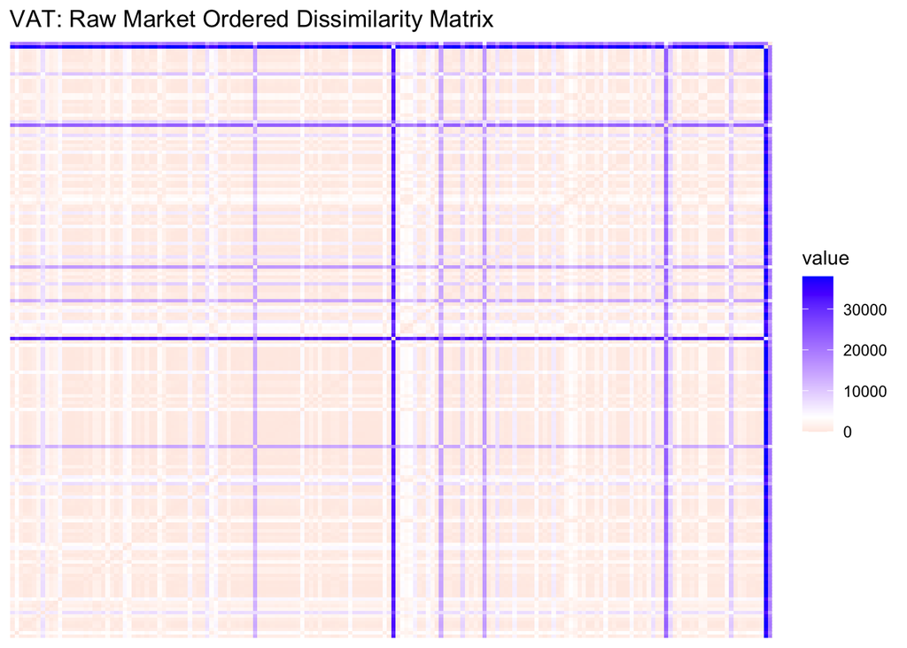

```r
h_market$plot + ggplot2::ggtitle("VAT: Raw Market Ordered Dissimilarity Matrix")
```

### 2.2.2 PAM Clustering on Raw Market Data

#### Search for Optimal $k$ `market`

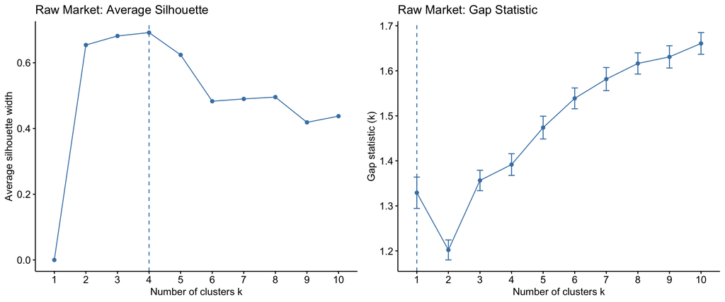

```r
set.seed(seed)
# PAM FOR MARKET STATISTICS
# Assessing optimal no of cluster
# NBClust etc.

market_sil <- fviz_nbclust(market,
                           FUNcluster = pam,
                           method = c("silhouette"),
                           k.max = 10) +
  ggplot2::ggtitle("Raw Market: Average Silhouette")

market_gap <- fviz_nbclust(market,
                           FUNcluster = pam,
                           method = c("gap_stat"),
                           k.max = 10) +
  ggplot2::ggtitle("Raw Market: Gap Statistic")

market_k <- pamk(market,
                 krange = 3:10)

gridExtra::grid.arrange(market_sil, market_gap, ncol = 2)
```

Optimal number of clusters for `market` dataset: 4

#### Apply PAM

```
## Too few points to calculate an ellipse
```

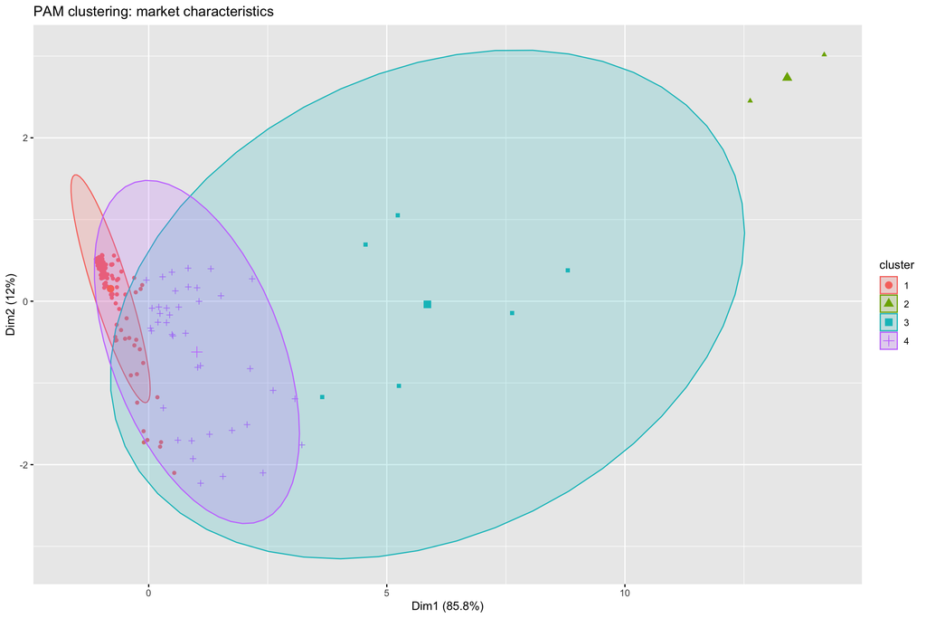

```r
market_pam <- pam(market, market_k$nc)

p_market <- fviz_cluster(market_pam, data = market,
             geom = "point",
             ellipse.type = "norm",
             show.clust.cent = TRUE,
             main = "PAM clustering: market characteristics")

p_market
```

```r
market_pam_kcca <- flexclust::as.kcca(market_pam, market)
```

```
## Found more than one class "kcca" in cache; using the first, from namespace 'flexclust'
```

```
## Also defined by 'kernlab'
```

```
## Found more than one class "kcca" in cache; using the first, from namespace 'flexclust'
```

```
## Also defined by 'kernlab'
```

```r
pMarketStripes <- grid.grabExpr(stripes(market_pam_kcca))
pMarketSil <- fviz_silhouette(market_pam)
```

```
##   cluster size ave.sil.width
## 1       1  128          0.83
## 2       2    2          0.70
## 3       3    6          0.42
## 4       4   40          0.29
```

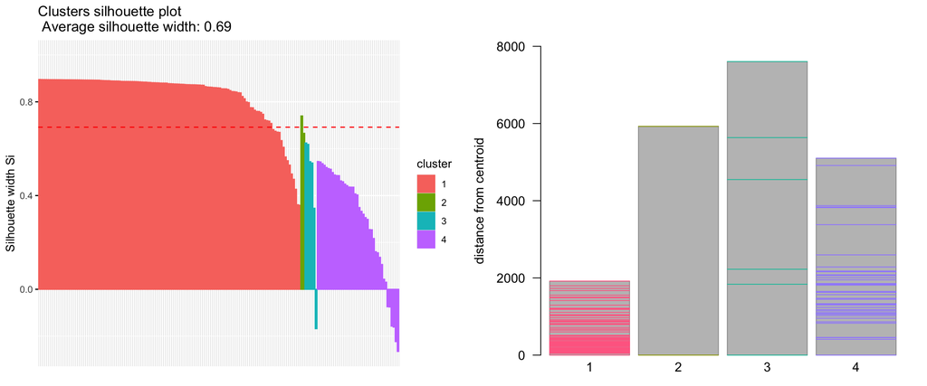

```r
gridExtra::grid.arrange(pMarketSil, pMarketStripes, ncol = 2)
```

On unscaled values, the first principal component absorbs >85% of variance and PAM isolates a handful of extreme high-volume colours into tiny outlier clusters while compressing the rest of the catalogue.

### 2.2.3 Transformations of Market Dataset

As observed in the previous section, partitioning of raw market data led to unbalanced clusters, with some taking only a few observations and one cluster putting over 120 of all the observations (so ~70% in one cluster). To counter uneven high-magnitude scales, we perform a skewness check, apply log transformations and standardise the dataset, so as to achieve more balanced clusters. To inspect how variables behave closely, let’s look at the distribution of the values with a histogram.

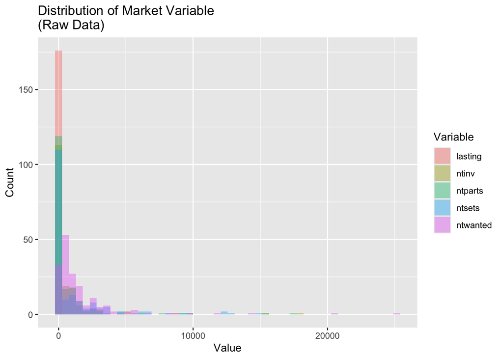

```r
marketRaw_plot <- market %>%
  pivot_longer(everything(),
               names_to = "Variable",
               values_to = "Value") %>%
  ggplot(aes(x = Value, fill = Variable)) +
  geom_histogram(bins = 50,
                 alpha = 0.4,
                 position = "identity") +
  labs(title = "Distribution of Market Variable\n(Raw Data)",
       x = "Value",
       y = "Count")

marketRaw_plot
```

To address the highly right-skewed data the aforementioned transformations are applied.

1. Log Transformation (with the `log1p` function): Applied to the count variables `ntparts`, `ntsets`, `ntwanted`, `ntinv` to reduce the effect of the long right tail, `lasting` is kept on its linear year scale because it is naturally bounded by LEGO’s production history.
2. Standardisation (with the `scale` function): Centres all five features to mean = 0 and standard deviation = 1, so all variables represent equal distances alongside each other.

Two plots below show the distribution before and after transformations.

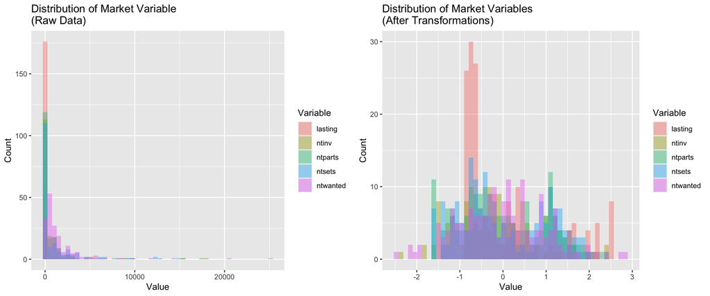

```r
marketTrans <- market
marketTrans[,c("ntparts", "ntsets", "ntwanted", "ntinv")] <- lapply(marketTrans[,c("ntparts", "ntsets", "ntwanted", "ntinv")], log1p)
marketTrans <- as.data.frame(scale(marketTrans))

marketTrans_plot <- marketTrans %>%
  pivot_longer(everything(),
               names_to = "Variable",
               values_to = "Value") %>%
  ggplot(aes(x = Value, fill = Variable)) +
  geom_histogram(bins = 50,
                 alpha = 0.4,
                 position = "identity") +
  labs(title = "Distribution of Market Variables\n(After Transformations)",
       x = "Value",
       y = "Count")

grid.arrange(marketRaw_plot, marketTrans_plot, ncol=2)
```

After the transformations, we re-evaluate clustering tendency and PAM to show how change of scale changes partitioning results.

### 2.2.4 Clustering Tendency on Transformed Market Data (`marketTrans`)

Evaluation of Hopkins’ statistic and assessment of its stability using Monte Carlo reveals a similar high level of clustering tendency. However, the ODM now exhibits a more diffuse structure than before, suggesting weaker block separation. The two methods above show inconclusive results; therefore, clustering is performed and analysed.

#### Hopkins’ Statistic (with Monte Carlo)

```r
set.seed(seed)
h_marketTrans <- get_clust_tendency(marketTrans,
                               round(0.2 * nrow(marketTrans)),
                               graph = TRUE,
                               gradient = list(low = "red", mid = "white", high = "blue"))


set.seed(seed)
h_marketTrans_mc <- replicate(mc_reps,
                         hopkins::hopkins(marketTrans,
                                          m = round(0.2 * nrow(marketTrans))))

knitr::kable(t(as.matrix(summary(h_marketTrans_mc))),
             caption = paste0("Monte Carlo Stability of Hopkins Statistic for Transformed Market Data (", mc_reps, "runs)"))
```

Monte Carlo Stability of Hopkins Statistic for Transformed Market Data (5000runs)

| Min. | 1st Qu. | Median | Mean | 3rd Qu. | Max. |
| --- | --- | --- | --- | --- | --- |
| 0.9976785 | 0.9993539 | 0.9996212 | 0.9995469 | 0.99982 | 0.9999713 |

#### VAT

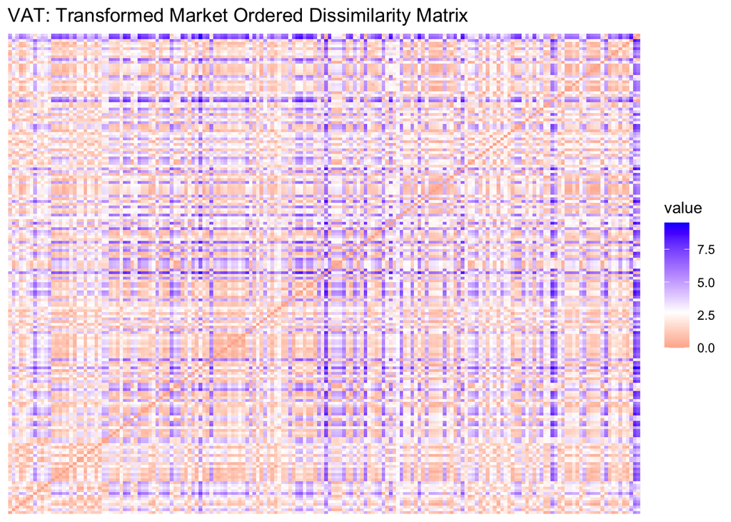

```r
h_marketTrans$plot + ggplot2::ggtitle("VAT: Transformed Market Ordered Dissimilarity Matrix")
```

### 2.2.5 PAM Clustering on Transformed Market Data

#### Search for Optimal $k$ `marketTrans`

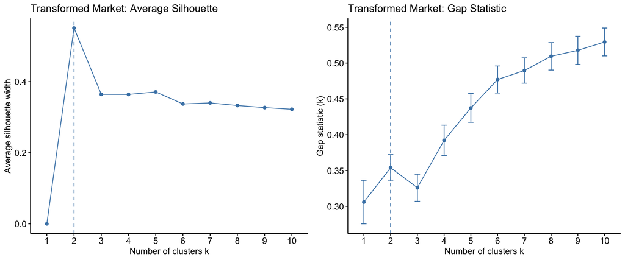

```r
set.seed(seed)
marketTrans_sil <- fviz_nbclust(marketTrans,
                           FUNcluster = pam,
                           method = c("silhouette"),
                           k.max = 10) +
  ggplot2::ggtitle("Transformed Market: Average Silhouette")

marketTrans_gap <- fviz_nbclust(marketTrans,
                           FUNcluster = pam,
                           method = c("gap_stat"),
                           k.max = 10) +
  ggplot2::ggtitle("Transformed Market: Gap Statistic")

marketTrans_k <- pamk(marketTrans,
                 krange = 3:10)

gridExtra::grid.arrange(marketTrans_sil, marketTrans_gap, ncol = 2)
```

Optimal number of clusters for `marketTrans` dataset: 5

#### PAM clustering and Basic Statistics

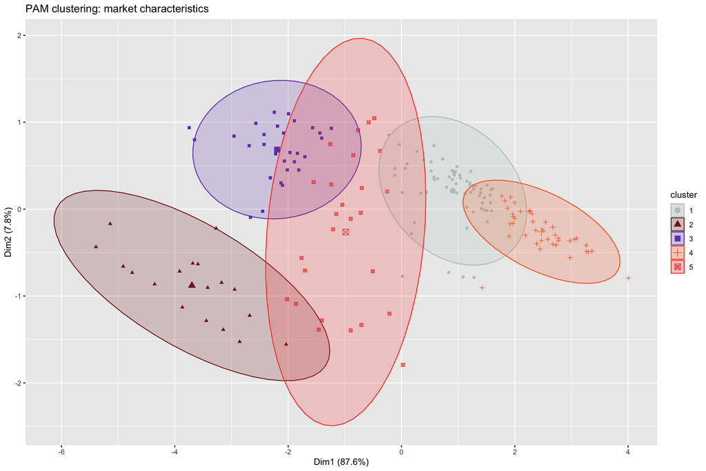

```r
marketTrans_pam <- pam(marketTrans, marketTrans_k$nc)

p_marketTrans <- fviz_cluster(marketTrans_pam, data = marketTrans,
             geom = "point",
             ellipse.type = "norm",
             show.clust.cent = TRUE,
             palette = bricklink$hexNumber[marketTrans_pam$id.med],
             main = "PAM clustering: market characteristics")

p_marketTrans
```

```r
marketTrans_pam_kcca <- flexclust::as.kcca(marketTrans_pam, marketTrans)
pMarketTransStripes <- grid.grabExpr(stripes(marketTrans_pam_kcca, col =bricklink$hexNumber[marketTrans_pam$id.med]))
pMarketTransSil <- fviz_silhouette(marketTrans_pam, palette = bricklink$hexNumber[marketTrans_pam$id.med])
```

```
##   cluster size ave.sil.width
## 1       1   63          0.35
## 2       2   18          0.46
## 3       3   29          0.52
## 4       4   40          0.39
## 5       5   26          0.16
```

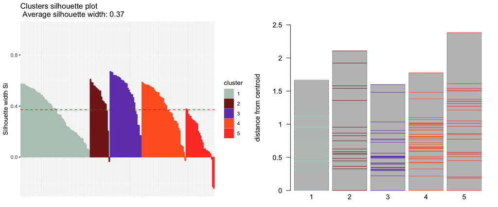

```r
gridExtra::grid.arrange(pMarketTransSil, pMarketTransStripes, ncol = 2)
```

### 2.2.6 Partitioning of Market Characteristics: Evaluation and Interpretation

Partitioning of Market Characteristics is evaluated across three criteria:

- Separation (Average Silhouette Width; Calinski–Harabasz (CH) Index)
- Stability (Bootstrap Resampling with Jaccard Similarity)
- Descriptive profiling

#### Separation and Quality

To start we assess the internal validity of the clusters.

1. Average Silhouette Width: already used earlier in this project, is a measure of how similar each point is to its own cluster compared to the nearest neighbouring cluster.
2. Calinski-Harabasz Index (CH): Computes the ratio of between-cluster to within-cluster dispersion. The higher the value, the denser and better separated the partitions are.

```r
sepQualTable <- data.frame(
  row.names = c("Number of Clusters (k)",
                "Average Silhouette Width",
                "Calinski-Harabasz Index"),
  value = round(c(length(marketTrans_pam$id.med),
                  marketTrans_pam$silinfo$avg.width,
                  fpc::calinhara(marketTrans,
                                 marketTrans_pam$clustering)), 3)
)

kable(sepQualTable, caption = "Separation and quality Metrics (`marketTrans`)")
```

Separation and quality Metrics (`marketTrans`)

|  | value |
| --- | --- |
| Number of Clusters (k) | 5.000 |
| Average Silhouette Width | 0.371 |
| Calinski-Harabasz Index | 245.144 |

Average Silhouette Width of 0.371 with a high CH Index of over 245 suggests moderately separated clusters. As seen on the plot earlier, there is some overlap between the groups; the clusters seem distinct but not completely disconnected.”

#### Stability

```r
rep_boot <- 500
```

To investigate the stability of the partition structure, we use `fpc::clusterboot` to bootstrap 500 random samples with replacement, re-run PAM and calculate the Jaccard similarity to original clusters.

$$J(C_1, C_2) = \frac{a}{a + b +
c}$$

- a: The number of pairs of points in the same cluster in both C<sub>1</sub> and C<sub>2</sub>.
- b: The number of pairs in the same cluster in C<sub>1</sub> but in different clusters in C<sub>1</sub>.
- c: The number of pairs in different clusters in C<sub>2</sub> but in the same cluster in C<sub>2</sub>.

The Jaccard similarity coefficient is a metric allowing us to assess whether the same points belong to the same clusters in separate partition objects. Optimal values are above 0.50 with 0.60-0.75 indicating valid underlying patterns and above 0.75 indicating highly stable clusters.

```r
set.seed(seed)

marketTrans_boot <- fpc::clusterboot(marketTrans,
                                     B = rep_boot,
                                     bootmethod = "boot",
                                     clustermethod = fpc::pamkCBI,
                                     k = marketTrans_k$nc,
                                     usepam = T,
                                     count = F)

stabilityTable <- data.frame(Cluster = seq_len(marketTrans_k$nc),
                             Size = as.vector(table(marketTrans_pam$clustering)),
                             Medoid = rownames(marketTrans)[marketTrans_pam$id.med],
                             Mean_Jaccard  = round(marketTrans_boot$bootmean, 3),
                             Dissolved_Pct = round((marketTrans_boot$bootbrd / marketTrans_boot$B) * 100, 1),
                             Recovered_Pct = round((marketTrans_boot$bootrecover / marketTrans_boot$B) * 100, 1)
)

kable(stabilityTable, caption = paste0("Bootstrap Cluster Stability (", marketTrans_boot$B, " Resamples)"))
```

Bootstrap Cluster Stability (500 Resamples)

| Cluster | Size | Medoid | Mean_Jaccard | Dissolved_Pct | Recovered_Pct |
| --- | --- | --- | --- | --- | --- |
| 1 | 63 | Trans-Aqua | 0.705 | 10.4 | 35.4 |
| 2 | 18 | Dark Red | 0.866 | 1.2 | 85.4 |
| 3 | 29 | Dark Purple | 0.767 | 2.0 | 53.8 |
| 4 | 40 | Dark Salmon | 0.799 | 3.8 | 58.6 |
| 5 | 26 | Trans-Neon Orange | 0.523 | 58.8 | 23.4 |

The bootstrapping reveals that the clusters are mostly concrete and stable.

#### Profiling of The Clusters and Interpretations

Even though PAM is fitted on the `marketTrans` dataset, cluster profiling maps the assignments back onto the original `market` scale, so that all values are directly readable and interpretable. The characterisation uses three sources of information to interpret the profile:

- Medoid Examination: Inspects the exact LEGO colour serving as each cluster centre.
- Descriptive Cluster Profiles: Summarises cluster sizes, original-scale medians, and the top three colours by set appearances (`Most_Sets`) and marketplace demand (`Most_Wanted`).
- Standardized Profile Plots: Compares median Z-scores across all five features via a multi-cluster line plot and faceted bar charts.

```r
market_medoids <- market[marketTrans_pam$id.med,]
market_medoids$cluster <- seq_len(marketTrans_k$nc)
kable(market_medoids,
      caption = "Cluster Medoids\nRepresentative LEGO Colours, Values on Original Scale")
```

Cluster Medoids Representative LEGO Colours, Values on Original Scale

|  | ntparts | ntsets | ntwanted | ntinv | lasting | cluster |
| --- | --- | --- | --- | --- | --- | --- |
| Trans-Aqua | 39 | 36 | 535 | 56 | 3 | 1 |
| Dark Red | 2194 | 2536 | 4450 | 2286 | 69 | 2 |
| Dark Purple | 1317 | 1729 | 2782 | 1441 | 26 | 3 |
| Dark Salmon | 5 | 4 | 188 | 8 | 0 | 4 |
| Trans-Neon Orange | 247 | 1041 | 1024 | 327 | 30 | 5 |

```r
market_profile <- market %>%
  mutate(colour = rownames(market),
         cluster = factor(marketTrans_pam$clustering)) %>%
  group_by(cluster) %>%
  summarise(
    count = n(),
    Parts = round(median(ntparts)),
    Sets = round(median(ntsets)),
    Wanted = round(median(ntwanted)),
    Inventory = round(median(ntinv)),
    Lasting = round(median(lasting)),
    Most_Sets = paste(head(colour[order(-ntsets)],3), collapse = ", "),
    Most_Wanted = paste(head(colour[order(-ntwanted)],3), collapse = ", "),
    .groups = "drop")

kable(market_profile, caption = "Market Cluster Profiles\nMedians on Original Scale")
```

Market Cluster Profiles Medians on Original Scale

| cluster | count | Parts | Sets | Wanted | Inventory | Lasting | Most_Sets | Most_Wanted |
| --- | --- | --- | --- | --- | --- | --- | --- | --- |
| 1 | 63 | 37 | 31 | 545 | 60 | 5 | Satin Trans-Light Blue, Neon Yellow, Satin Trans-Clear | Very Light Bluish Gray, Light Brown, Rust |
| 2 | 18 | 2304 | 4747 | 5324 | 2682 | 69 | Black, White, Red | White, Black, Red |
| 3 | 29 | 1010 | 1860 | 2782 | 1157 | 25 | Light Bluish Gray, Dark Bluish Gray, Orange | Light Bluish Gray, Dark Bluish Gray, Orange |
| 4 | 40 | 3 | 5 | 200 | 8 | 2 | Glitter Trans-Dark Pink, Satin Trans-Bright Green, Reddish Copper | Chrome Black, Dark Yellow, Bionicle Silver |
| 5 | 26 | 238 | 564 | 1059 | 294 | 30 | Trans-Red, Trans-Yellow, Trans-Orange | Chrome Silver, Nougat, Medium Tan |

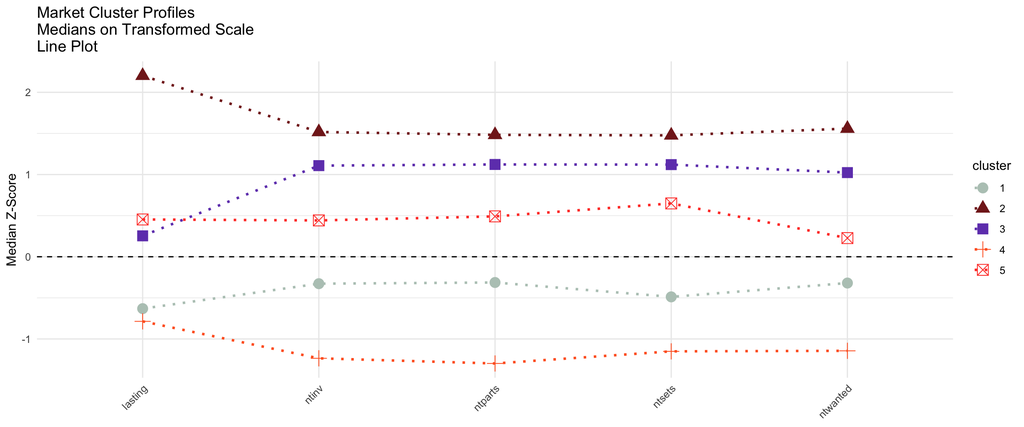

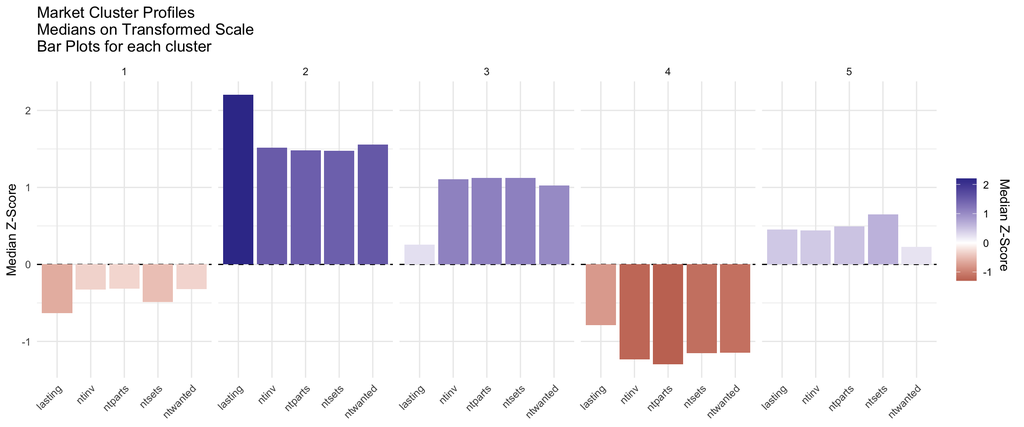

```r
marketTrans_z <- marketTrans %>%
  mutate(cluster = factor(marketTrans_pam$clustering)) %>%
  group_by(cluster) %>%
  summarise(across(everything(),
                   median)) %>%
  tidyr::pivot_longer(-cluster,
                      names_to = "Variable",
                      values_to = "Median_Z")

ggplot(marketTrans_z,
       aes(Variable,
           Median_Z,
           color = cluster,
           shape = cluster,
           group = cluster)) +
  geom_hline(yintercept = 0, linetype = "dashed") +
  geom_line(linewidth = 1, linetype = "dotted") +
  geom_point(size = 4) +
  scale_color_manual(
    values = bricklink$hexNumber[marketTrans_pam$id.med]) +
  labs(x = NULL,
       y = "Median Z-Score",
       title = "Market Cluster Profiles\nMedians on Transformed Scale\nLine Plot") +
  theme_minimal() +
  theme(axis.text.x = element_text(angle = 45,
                                   hjust = 1))

ggplot(marketTrans_z,
       aes(Variable, Median_Z, fill = Median_Z)) +
  geom_hline(yintercept = 0, linetype = "dashed") +
  geom_col(width = 0.9) +
  scale_fill_gradient2(
    low = "red4",
    name = "Median Z-Score") +
  facet_wrap(~ cluster, ncol = 5) +
  labs(x = NULL,
       y = "Median Z-Score",
       title = "Market Cluster Profiles\nMedians on Transformed Scale\nBar Plots for each cluster") +
  theme_minimal() +
  theme(axis.text.x = element_text(angle = 45,
                                   hjust = 1),
        legend.position = "right",
        legend.title = element_text(angle = 270),
        legend.title.position = "right")
```

#### Interpretation of the Clusters

- **Cluster 1: UNIQUES** ($n = 63$ / Medoid: Trans-Aqua):
  - Achieves just below average scores in all domains. Groups newer specialty colours (Satin Trans-Light Blue, Neon Yellow) alongside short-lived historical shades (Very Light Bluish Gray, Rust).
- **Cluster 2: STAPLES** ($n = 18$ / Medoid: Dark Red)
  - Dominates every metric; these are the foundations of the LEGO palette with Black, White, and Red, and have been in production for most of the company’s history with a wide variety of uses and massive part diversity.
- **Cluster 3: NEW LEADERS** ($n = 29$ / Medoid: Dark Purple):
  - These colours exhibit high production volume and demand but without a long history. This cluster reflects the LEGO palette overhaul during the 2000s, with new colours replacing some of the old basics.
- **Cluster 4: NOVELTIES** ($n = 40$ / Medoid: Dark Salmon):
  - Ranks lowest on every variable. This cluster collects colours with the lowest median life-span of 2 years, suggesting experimental and not well-established colours. These include promotional or theme-exclusive colours.
- **Cluster 5: MISCELLANEOUS** ($n = 26$ / Medoid: Trans-Neon Orange):
  - As evaluated earlier, the most unstable of the clusters. Slightly above average scores; group with the second longest-running production. Although included in a sizeable number of sets, its demand is not especially high. These include classic translucent colours and steady secondary tones.

### 2.2.7 Market Characteristics Summary of Clustering

Clustering on the raw `market` dataset resulted in a heavily skewed, unbalanced partition due to high-magnitude differences across the variables. Raw inventory and counts of marketplace info reach thousands, while lifespan spans only a few decades; pairwise distance comparisons were driven mostly by the outliers. This resulted in isolating a handful of colours into tiny groups while around 70% of the colour catalogue were put into a single cluster.

Finally, transformations of raw data proved `lasting` to be one of the crucial features in differentiating between cluster profiles. PAM performed on `marketTrans` allowed us to create meaningful clusters; descriptive profiling and Z-score evaluation showed how the grouped colours reveal specific market archetypes.

## 2.3 Colour Characteristics Clustering

After analysing market information on LEGO colour we move forward to understand whether the LEGO colours can be grouped into a few main palettes based on their CIELAB values. This section will rely on the `labInfo` dataset prepared in the 2.1.1.

### 2.3.1 Clustering Tendency on CIELAB values

#### Hopkins’ Statistic (with Monte Carlo)

The introductory analysis of clustering tendency reveals that the $H$ value for CIELAB values is less stable than it was in the market dataset, although mean and median values remain high enough to justify partitioning. Visual assessment exhibits rather noisy random data, suggesting that clusters may not be distinct.

```r
set.seed(seed)
h_labInfo <- get_clust_tendency(labInfo,
                               round(0.2 * nrow(labInfo)),
                               graph = TRUE,
                               gradient = list(low = "red", mid = "white", high = "blue"))


set.seed(seed)
h_labInfo_mc <- replicate(mc_reps,
                         hopkins::hopkins(labInfo,
                                          m = round(0.2 * nrow(labInfo))))

knitr::kable(t(as.matrix(summary(h_labInfo_mc))),
             caption = paste0("Monte Carlo Stability of Hopkins Statistic for CIELAB Values (", mc_reps, "runs)"))
```

Monte Carlo Stability of Hopkins Statistic for CIELAB Values (5000runs)

| Min. | 1st Qu. | Median | Mean | 3rd Qu. | Max. |
| --- | --- | --- | --- | --- | --- |
| 0.7879515 | 0.9325587 | 0.9487261 | 0.9441648 | 0.960531 | 0.9893763 |

#### VAT

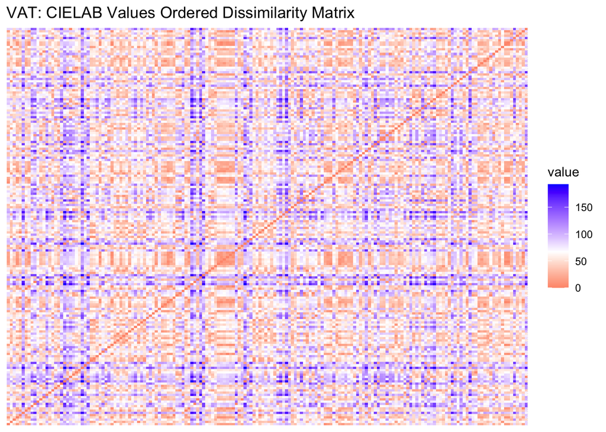

```r
h_labInfo$plot + ggplot2::ggtitle("VAT: CIELAB Values Ordered Dissimilarity Matrix")
```